# Competition simulations without light

Daniel Gschwentner

2024-06-21

## Notes for modelling/to-do

- Remove light from models, run simulation and evaluate competition
  - Removal of light allows diatoms to compete. Diatoms have highest K<sub>Light</sub> and are therefore the least competitive taxa for light.
  - You should re-run all simulations with and without light to evaluate how light availability influences competition. You’ll probably find that the high K<sub>Light</sub> completely excludes diatoms, and that diatoms will dominate in Droop model instead of green algae.
- Include light as gradient in model (i.e. different light environments). Run models and try to plot results across 3 axes or as surface/contour. You could also facet across light to create pseudo-3rd axis.
  - Appears to be a N-P-light trade-off in the models: if light is low, cyanos win because they have the lowest K<sub>Light</sub>; increasing light allows for green algae to compete and dominate; interestingly, when light is included in the models, diatoms never dominate.
- Should really rename the Michaelis Menten models to Monod model. This will create quite a bit of confusion if you don’t.

## Setup, load data and packages

```r
pck <- c("deSolve", "tidyverse", "cowplot", "ggsci")
lapply(pck, require, character.only = T)
theme_set(theme_cowplot() + theme(legend.justification = "center"))
# load ODE models
# saved in external files for convenience
#mich.singe
source("models/mich_single.R") # michaelis menten kinetics, one algae species; model 1 in Carly's framework
# mich.triple
source("models/mich_trip_noLight.R")# michaelis menten kinites, three algae species; model 2 in Carly's framework
# droop.single
source("models/droop_single.R") # droop model, one algae species; model 3 in Carly's framework
# droop.tripl
source("models/droop_trip_noLight.R") # droop model, three algae species; model 4 in Carly's framework
```

```r
# TN and TP load data
# corman2023 <- read_csv("Corman2023 metabolism result.csv")
# range(corman2023$TN_load, na.rm = T)
# hist(corman2023$TN_load)
# range(corman2023$TP_load, na.rm = T)
# hist(corman2023$TP_load)

# trait data
# median values
traits <- read_csv("data4input/phyto_traits4models_21June2024.csv")[,-1]
# quantile 25
traitsq25 <- read_csv("data4input/phyto_traits4models_21June2024_25thquantile.csv")[,-1]
# quantile 75
traitsq75 <- read_csv("data4input/phyto_traits4models_21June2024_75thquantile.csv")[,-1]
```

# Phytoplankton competition simulations

### Model simulations

Two models are compared:

1. Model with static cell stoichiometry and Michaelis-Menten uptake kinetics.
   1. Requires half saturation constants for light, N and P; minimum cellular N and P quotas.
2. Model with flexible cell stoichiometry following Droop formulation.
   1. Requires half saturation constants for light, N and P; minimum cellular N and P quotas; maximum uptake rates for N and P.

### Phytoplankton traits

The phytoplankton traits used to parameterize the models are shown in the table below.

```r
knitr::kable(traits, caption = "Median trait value")
```

Median trait value

| Trait | diatoms | greens | cyanos | average |
| --- | --- | --- | --- | --- |
| K_N_mgL | 0.064 | 0.036 | 0.033 | 0.0500 |
| K_P_mgL | 0.005 | 0.028 | 0.026 | 0.0165 |
| Qmax_mg_N_mg_C | 0.201 | 0.068 | 0.023 | 0.1345 |
| Qmax_mg_P_mg_C | 0.146 | 0.015 | 0.008 | 0.0805 |
| Qmin_mg_N_mg_C | 0.155 | 0.025 | 0.010 | 0.0900 |
| Qmin_mg_P_mg_C | 0.020 | 0.001 | 0.001 | 0.0105 |
| Vmax_mg_N_mg_C | 4.490 | 0.416 | 0.034 | 2.4530 |
| Vmax_mg_P_mg_C | 0.608 | 0.243 | 0.113 | 0.4255 |
| umax_N | 0.860 | 1.320 | 0.860 | 1.0900 |
| umax_P | 0.610 | 0.630 | 0.655 | 0.6200 |
| K_light | 167.800 | 165.250 | 88.600 | 166.5250 |
| umax | 0.455 | 0.875 | 0.640 | 0.6650 |

```r
knitr::kable(traitsq25, caption = "25th quantile trait value")
```

25th quantile trait value

| Trait | diatoms | greens | cyanos |
| --- | --- | --- | --- |
| K_N_mgL | 0.038 | 0.026 | 0.026 |
| K_P_mgL | 0.002 | 0.018 | 0.015 |
| Qmax_mg_N_mg_C | 0.172 | 0.056 | 0.015 |
| Qmax_mg_P_mg_C | 0.098 | 0.008 | 0.005 |
| Qmin_mg_N_mg_C | 0.065 | 0.014 | 0.003 |
| Qmin_mg_P_mg_C | 0.008 | 0.001 | 0.000 |
| Vmax_mg_N_mg_C | 2.131 | 0.171 | 0.013 |
| Vmax_mg_P_mg_C | 0.211 | 0.077 | 0.052 |
| umax_N | 0.860 | 1.275 | 0.670 |
| umax_P | 0.520 | 0.405 | 0.525 |
| K_light | 90.900 | 113.925 | 52.250 |
| umax | 0.288 | 0.790 | 0.557 |

```r
knitr::kable(traitsq75, caption = "75th quantile trait value")
```

75th quantile trait value

| Trait | diatoms | greens | cyanos |
| --- | --- | --- | --- |
| K_N_mgL | 0.087 | 0.056 | 0.047 |
| K_P_mgL | 0.024 | 0.042 | 0.045 |
| Qmax_mg_N_mg_C | 0.358 | 0.102 | 0.031 |
| Qmax_mg_P_mg_C | 0.152 | 0.034 | 0.010 |
| Qmin_mg_N_mg_C | 0.496 | 0.037 | 0.028 |
| Qmin_mg_P_mg_C | 0.045 | 0.002 | 0.001 |
| Vmax_mg_N_mg_C | 5.654 | 0.979 | 0.048 |
| Vmax_mg_P_mg_C | 0.928 | 0.551 | 0.182 |
| umax_N | 0.860 | 1.500 | 1.180 |
| umax_P | 0.730 | 1.000 | 0.868 |
| K_light | 182.300 | 202.900 | 98.550 |
| umax | 0.700 | 1.230 | 0.740 |

The following set-up is used

- Species 1 = diatoms
- Species 2 = green algae
- Species 3 = cyanobacteria

### Sensitivity analysis

To get around the issue of having to simultaneously vary trait parameters for 3 species, I decided to do a pseudo-sensitivity analysis. I ran the models with median trait values as well as the 25<sup>th</sup> and 75<sup>th</sup> quantile for each trait for each taxon. This approach should incorporate a wider range of the “trait-space” and of competitive outcomes. If we see similar results across all simulations, it suggests that certain taxa are on average more competitive than other taxa. Carly is going to work on a sensitivity analysis with one-single taxa to evaluate which traits are the most sensitive/important.

# Model runs

Set-up model parameters

```r
# timesteps
times <- 1:500
# loads
# loads
loads <- expand.grid(Pin = seq(10, 500,10 ),
                                Nin = seq(10,1000 , 50))
```

## Median trait values

### Michaelis-Menten/static stoichiometry

```r
params.mich.trip <- c(
  # lake parameters
  SA= 1,        # lake surface area in km2
  zmix = 2, # lake mixing depth in m
  Pin = NA, # P inflow concentration in mg P m^-3
  Nin = NA, # N inflow concentration in mg N m^-3

  # light parameters
  I0 = NA, # incident light
  kBg= 0.1,     # background light attenuation (m-1)/(g C m-3); 0.1-5.6 from Jager & Diehl
  kA=0.0003, # algal light attenuation (m-1)/(mg C m-3); 0.0003 from Jager & Diehl

  # algae physiology parameters
  umax1 = traits[12, "diatoms"],
  umax2 = traits[12, "greens"],
  umax3 = traits[12, "cyanos"],
  lA=0.1,           # mortality rate day-1
  v=0.1,            # m d-1; sinking loss of algae
  KLight1 = traits[11, "diatoms"], # light half sat constant
  KLight2 = traits[11, "greens"], # light half sat constant
  KLight3 = traits[11, "cyanos"], # light half sat constant
  KP1 = traits[2, "diatoms"] * 1000, # phosphorus half sat constant in mg P m^-3 f
  KP2 = traits[2, "greens"] * 1000,
  KP3 = traits[2, "cyanos"] * 1000,
  QP1 = traits[6, "diatoms"], # algae cell P quota in mg P mg^-1 C^-1
  QP2 = traits[6, "greens"],
  QP3 = traits[6, "cyanos"],
  KN1 = traits[1, "diatoms"] * 1000, # nitrogen half sat constant in mg N m^-3
  KN2 = traits[1, "greens"] * 1000,
  KN3 = traits[1, "cyanos"] * 1000,
  QN1 = traits[5, "diatoms"], # algae cell N quota in mg N mg^-1 C^-1
  QN2 = traits[5, "greens"],
  QN3 = traits[5, "cyanos"]
)
names(params.mich.trip) <- c("SA", "zmix", "Pin", "Nin", "I0", "kBg", "kA",
                             "umax1", "umax2", "umax3", "lA", "v",
                             "KLight1", "KLight2", "KLight3",
                             "KP1", "KP2", "KP3", "QP1", "QP2", "QP3",
                             "KN1", "KN2", "KN3", "QN1", "QN2", "QN3")
names(params.mich.trip)
```

```
##  [1] "SA"      "zmix"    "Pin"     "Nin"     "I0"      "kBg"     "kA"
##  [8] "umax1"   "umax2"   "umax3"   "lA"      "v"       "KLight1" "KLight2"
## [15] "KLight3" "KP1"     "KP2"     "KP3"     "QP1"     "QP2"     "QP3"
## [22] "KN1"     "KN2"     "KN3"     "QN1"     "QN2"     "QN3"
```

```r
params.mich.trip <- unlist(params.mich.trip)
traits
```

```
## # A tibble: 12 × 5
##    Trait          diatoms  greens cyanos  average
##    <chr>            <dbl>   <dbl>  <dbl>    <dbl>
##  1 K_N_mgL          0.064   0.036  0.033   0.05
##  2 K_P_mgL          0.005   0.028  0.026   0.0165
##  3 Qmax_mg_N_mg_C   0.201   0.068  0.023   0.134
##  4 Qmax_mg_P_mg_C   0.146   0.015  0.008   0.0805
##  5 Qmin_mg_N_mg_C   0.155   0.025  0.01    0.09
##  6 Qmin_mg_P_mg_C   0.02    0.001  0.001   0.0105
##  7 Vmax_mg_N_mg_C   4.49    0.416  0.034   2.45
##  8 Vmax_mg_P_mg_C   0.608   0.243  0.113   0.426
##  9 umax_N           0.86    1.32   0.86    1.09
## 10 umax_P           0.61    0.63   0.655   0.62
## 11 K_light        168.    165.    88.6   167.
## 12 umax             0.455   0.875  0.64    0.665
```

```r
sim.mich.menten.triple <- lapply(1:nrow(loads), function(i) {
  params.mich.trip["Pin"] = loads[i, "Pin"]
  params.mich.trip["Nin"] = loads[i, "Nin"]
  y <- c("A1" = 100,
         "A2" = 100,
         "A3" = 100,
         "P" = loads[i, "Pin"],
         "N" = loads[i, "Nin"])

  run <- ode(y, times, parms = params.mich.trip,func = mich.trip)
  return(run[max(times),])

})

sim.mich.menten.triple <- do.call(rbind, sim.mich.menten.triple)
sim.mich.menten.triple <- as_data_frame(sim.mich.menten.triple)
sim.mich.menten.triple$Pin <- loads$Pin
sim.mich.menten.triple$Nin <- loads$Nin
sim.mich.menten.triple$NPinflow <- loads$NPinmolar

# Add info on which species one
sim.mich.menten.triple <- sim.mich.menten.triple %>%
  mutate(winner = max.col(sim.mich.menten.triple[,2:4]),
         winner = gsub(1, "Diatom", winner),
         winner = gsub(2, "Greens", winner),
         winner = gsub(3, "Cyanos", winner))
table(sim.mich.menten.triple$winner)
```

```
##
## Cyanos Diatom
##    839    161
```

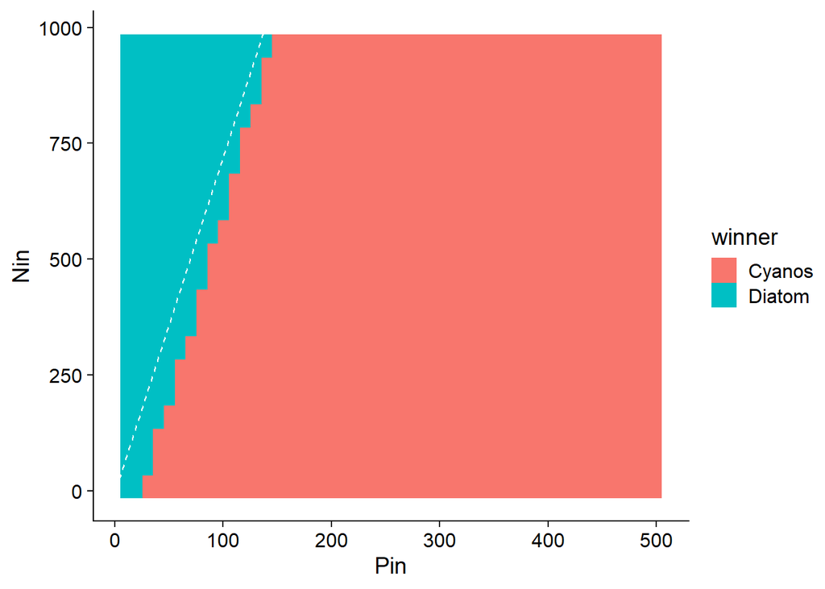

```r
sim.mich.menten.triple %>%
  ggplot(aes(Pin, Nin, fill = winner)) +
  geom_raster() +
  geom_abline(slope = 16 * 14.007/30.974, lty = "dashed", col = "white")
```

### Droop formation/flexible stoichiometry

```r
params.droop.triple <- c(
  # lake parameters
  SA= 1,        # lake surface area in km2
  zmix = 2, # lake mixing depth in m
  Pin = NA, # P inflow concentration in mg P m^-3
  Nin = NA, # N inflow concentration in mg N m^-3

  # light parameters
  I0 = NA, # surface light
  kBg= 0.1,     # background light attenuation (m-1)/(g C m-3); 0.1-5.6 from Jager & Diehl
  kA=0.0003, # algal light attenuation (m-1)/(mg C m-3); 0.0003 from Jager & Diehl

  # algae physiology parameters
  umax1 = traits[12, "diatoms"],
  umax2 = traits[12, "greens"],
  umax3 = traits[12, "cyanos"],

  lA=0.1,           # mortality rate day-1
  v= 0.1,           # m d-1; sinking loss of algae
  KLight1 = traits[11, "diatoms"], # light half sat constant
  KLight2 = traits[11, "greens"], # light half sat constant
  KLight3 = traits[11, "cyanos"], # light half sat constant

  KP1 = traits[2, "diatoms"] * 1000, # phosphorus half sat constant in mg P m^-3 f
  KP2 = traits[2, "greens"] * 1000,
  KP3 = traits[2, "cyanos"] * 1000,
  minQP1 = traits[6, "diatoms"], # algae cell P quota in mg P mg^-1 C^-1 f
  minQP2 = traits[6, "greens"],
  minQP3 = traits[6, "cyanos"],
  upP1 = traits[4, "diatoms"], # max uptake rate P per day in mg P mg C^-1 day^-1
  upP2 = traits[4, "greens"],
  upP3 = traits[4, "cyanos"],
  KN1 = traits[1, "diatoms"] * 1000, # nitrogen half sat constant in mg N m^-3
  KN2 = traits[1, "greens"] * 1000,
  KN3 = traits[1, "cyanos"] * 1000,
  minQN1 = traits[5, "diatoms"], # algae cell N quota in mg N mg^-1 C^-1 f
  minQN2 = traits[5, "greens"],
  minQN3 = traits[5, "cyanos"],
  upN1 = traits[3, "diatoms"], # max uptake rate N per day in mg N mg C^-1 day^-1
  upN2 = traits[3, "greens"],
  upN3 = traits[3, "cyanos"]
)



names(params.droop.triple) <- c("SA", "zmix", "Pin", "Nin", "I0", "kBg", "kA",
                             "umax1", "umax2", "umax3", "lA", "v",
                             "KLight1", "KLight2", "KLight3",
                             "KP1", "KP2", "KP3", "minQP1", "minQP2", "minQP3",
                             "upP1", "upP2", "upP3",
                             "KN1", "KN2", "KN3", "minQN1", "minQN2", "minQN3",
                             "upN1", "upN2", "upN3")
names(params.droop.triple)
```

```
##  [1] "SA"      "zmix"    "Pin"     "Nin"     "I0"      "kBg"     "kA"
##  [8] "umax1"   "umax2"   "umax3"   "lA"      "v"       "KLight1" "KLight2"
## [15] "KLight3" "KP1"     "KP2"     "KP3"     "minQP1"  "minQP2"  "minQP3"
## [22] "upP1"    "upP2"    "upP3"    "KN1"     "KN2"     "KN3"     "minQN1"
## [29] "minQN2"  "minQN3"  "upN1"    "upN2"    "upN3"
```

```r
params.droop.triple <- unlist(params.droop.triple)
```

```r
sim.droop.triple <- lapply(1:nrow(loads), function(i) {
  params.droop.triple["Pin"] = loads[i, "Pin"]
  params.droop.triple["Nin"] = loads[i, "Nin"]
  y <- c("A1" = 100,
         "A2" = 100,
         "A3" = 100,
         "P" = loads[i, "Pin"],
         "N" = loads[i, "Nin"],
         "QP1" = 0.015,
         "QP2" = 0.015,
         "QP3" = 0.015,
         "QN1" = 0.1,
         "QN2" = 0.1,
         "QN3" = 0.1)

  run <- ode(y, times, parms = params.droop.triple, func = droop.trip)
  return(run[max(times),])

})

sim.droop.triple <- do.call(rbind, sim.droop.triple)
sim.droop.triple <- as_data_frame(sim.droop.triple)
sim.droop.triple$Pin <- loads$Pin
sim.droop.triple$Nin <- loads$Nin
sim.droop.triple$NPinflow <- loads$NPinmolar

# Add info on which species one
sim.droop.triple <- sim.droop.triple %>%
  mutate(winner = max.col(sim.droop.triple[,2:4]),
         winner = gsub(1, "Diatom", winner),
         winner = gsub(2, "Greens", winner),
         winner = gsub(3, "Cyanos", winner))
table(sim.droop.triple$winner)
```

```
##
## Diatom Greens
##     51    949
```

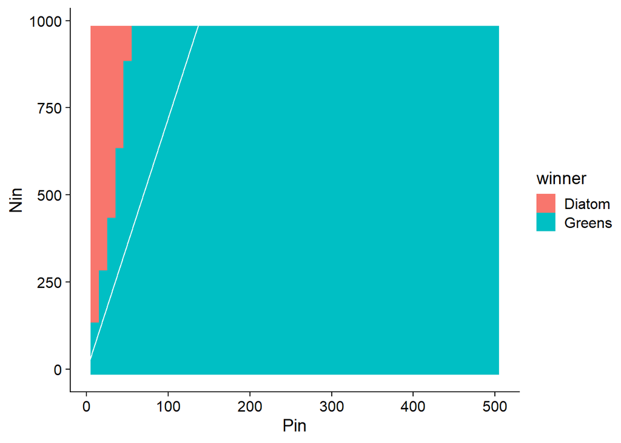

```r
sim.droop.triple %>%
  ggplot(aes(Pin, Nin, fill = winner)) +
  geom_raster() +
  geom_abline(intercept = 0, slope = (16*14.001)/30.974, col = "white")
```

## 25th quantile trait values

### Michaelis-Menten/static stoichiometry

```r
params.mich.trip.q25 <- c(
  # lake parameters
  SA= 1,        # lake surface area in km2
  zmix = 2, # lake mixing depth in m
  Pin = NA, # P inflow concentration in mg P m^-3
  Nin = NA, # N inflow concentration in mg N m^-3

  # light parameters
  I0 = NA, # incident light
  kBg= 0.1,     # background light attenuation (m-1)/(g C m-3); 0.1-5.6 from Jager & Diehl
  kA=0.0003, # algal light attenuation (m-1)/(mg C m-3); 0.0003 from Jager & Diehl

  # algae physiology parameters
  umax1 = traitsq25[12, "diatoms"],
  umax2 = traitsq25[12, "greens"],
  umax3 = traitsq25[12, "cyanos"],
  lA=0.1,           # mortality rate day-1
  v=0.1,            # m d-1; sinking loss of algae
  KLight1 = traitsq25[11, "diatoms"], # light half sat constant
  KLight2 = traitsq25[11, "greens"], # light half sat constant
  KLight3 = traitsq25[11, "cyanos"], # light half sat constant
  KP1 = traitsq25[2, "diatoms"] * 1000, # phosphorus half sat constant in mg P m^-3 f
  KP2 = traitsq25[2, "greens"] * 1000,
  KP3 = traitsq25[2, "cyanos"] * 1000,
  QP1 = traitsq25[6, "diatoms"], # algae cell P quota in mg P mg^-1 C^-1
  QP2 = traitsq25[6, "greens"],
  QP3 = traitsq25[6, "cyanos"],
  KN1 = traitsq25[1, "diatoms"] * 1000, # nitrogen half sat constant in mg N m^-3
  KN2 = traitsq25[1, "greens"] * 1000,
  KN3 = traitsq25[1, "cyanos"] * 1000,
  QN1 = traitsq25[5, "diatoms"], # algae cell N quota in mg N mg^-1 C^-1
  QN2 = traitsq25[5, "greens"],
  QN3 = traitsq25[5, "cyanos"]
)
names(params.mich.trip.q25) <- c("SA", "zmix", "Pin", "Nin", "I0", "kBg", "kA",
                             "umax1", "umax2", "umax3", "lA", "v",
                             "KLight1", "KLight2", "KLight3",
                             "KP1", "KP2", "KP3", "QP1", "QP2", "QP3",
                             "KN1", "KN2", "KN3", "QN1", "QN2", "QN3")
names(params.mich.trip.q25)
```

```
##  [1] "SA"      "zmix"    "Pin"     "Nin"     "I0"      "kBg"     "kA"
##  [8] "umax1"   "umax2"   "umax3"   "lA"      "v"       "KLight1" "KLight2"
## [15] "KLight3" "KP1"     "KP2"     "KP3"     "QP1"     "QP2"     "QP3"
## [22] "KN1"     "KN2"     "KN3"     "QN1"     "QN2"     "QN3"
```

```r
params.mich.trip.q25 <- unlist(params.mich.trip.q25)
```

```r
# issue occuring at row 34:35 of loads. dunno why

sim.mich.menten.triple.q25 <- lapply(1:nrow(loads), function(i) {
  params.mich.trip.q25["Pin"] = loads[i, "Pin"]
  params.mich.trip.q25["Nin"] = loads[i, "Nin"]
  y <- c("A1" = 100,
         "A2" = 100,
         "A3" = 100,
         "P" = loads[i, "Pin"],
         "N" = loads[i, "Nin"])

  run <- ode(y, times, parms = params.mich.trip.q25,func = mich.trip)
  return(run[max(times),])

})

sim.mich.menten.triple.q25 <- do.call(rbind, sim.mich.menten.triple.q25)
sim.mich.menten.triple.q25 <- as_data_frame(sim.mich.menten.triple.q25)
sim.mich.menten.triple.q25$Pin <- loads$Pin
sim.mich.menten.triple.q25$Nin <- loads$Nin
sim.mich.menten.triple.q25$NPinflow <- loads$NPinmolar

# Add info on which species one
sim.mich.menten.triple.q25 <- sim.mich.menten.triple.q25 %>%
  mutate(winner = max.col(sim.mich.menten.triple.q25[,2:4]),
         winner = gsub(1, "Diatom", winner),
         winner = gsub(2, "Greens", winner),
         winner = gsub(3, "Cyanos", winner))
table(sim.mich.menten.triple.q25$winner)
```

```
##
## Cyanos Diatom
##    829    171
```

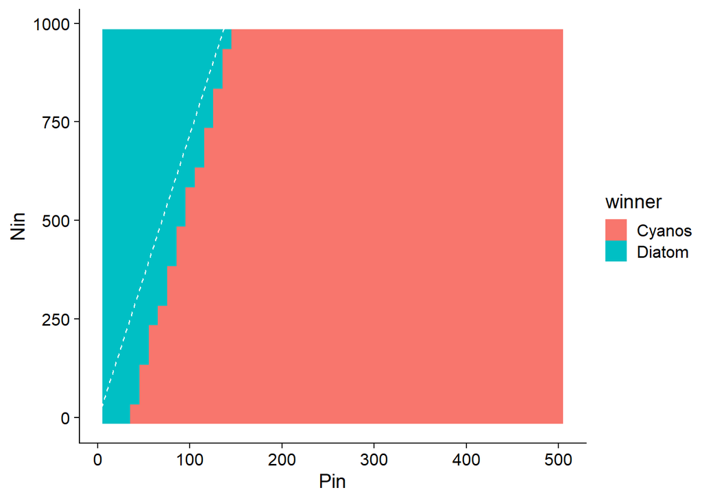

```r
sim.mich.menten.triple.q25 %>%
  ggplot(aes(Pin, Nin, fill = winner)) +
  geom_raster() +
  geom_abline(slope = 16 * 14.007/30.974, lty = "dashed", col = "white")
```

### Droop formation/flexible stoichiometry with quantile 25 trait parameters

```r
params.droop.triple.q25 <- c(
  # lake parameters
  SA= 1,        # lake surface area in km2
  zmix = 2, # lake mixing depth in m
  Pin = NA, # P inflow concentration in mg P m^-3
  Nin = NA, # N inflow concentration in mg N m^-3

  # light parameters
  I0 = NA, # surface light
  kBg= 0.1,     # background light attenuation (m-1)/(g C m-3); 0.1-5.6 from Jager & Diehl
  kA=0.0003, # algal light attenuation (m-1)/(mg C m-3); 0.0003 from Jager & Diehl

  # algae physiology parameters
  umax1 = traitsq25[12, "diatoms"],
  umax2 = traitsq25[12, "greens"],
  umax3 = traitsq25[12, "cyanos"],

  lA=0.1,           # mortality rate day-1
  v= 0.1,           # m d-1; sinking loss of algae
  KLight1 = traitsq25[11, "diatoms"], # light half sat constant
  KLight2 = traitsq25[11, "greens"], # light half sat constant
  KLight3 = traitsq25[11, "cyanos"], # light half sat constant

  KP1 = traitsq25[2, "diatoms"] * 1000, # phosphorus half sat constant in mg P m^-3 f
  KP2 = traitsq25[2, "greens"] * 1000,
  KP3 = traitsq25[2, "cyanos"] * 1000,
  minQP1 = traitsq25[6, "diatoms"], # algae cell P quota in mg P mg^-1 C^-1 f
  minQP2 = traitsq25[6, "greens"],
  minQP3 = traitsq25[6, "cyanos"],
  upP1 = traitsq25[4, "diatoms"], # max uptake rate P per day in mg P mg C^-1 day^-1
  upP2 = traitsq25[4, "greens"],
  upP3 = traitsq25[4, "cyanos"],
  KN1 = traitsq25[1, "diatoms"] * 1000, # nitrogen half sat constant in mg N m^-3
  KN2 = traitsq25[1, "greens"] * 1000,
  KN3 = traitsq25[1, "cyanos"] * 1000,
  minQN1 = traitsq25[5, "diatoms"], # algae cell N quota in mg N mg^-1 C^-1 f
  minQN2 = traitsq25[5, "greens"],
  minQN3 = traitsq25[5, "cyanos"],
  upN1 = traitsq25[3, "diatoms"], # max uptake rate N per day in mg N mg C^-1 day^-1
  upN2 = traitsq25[3, "greens"],
  upN3 = traitsq25[3, "cyanos"]
)



names(params.droop.triple.q25) <- c("SA", "zmix", "Pin", "Nin", "I0", "kBg", "kA",
                             "umax1", "umax2", "umax3", "lA", "v",
                             "KLight1", "KLight2", "KLight3",
                             "KP1", "KP2", "KP3", "minQP1", "minQP2", "minQP3",
                             "upP1", "upP2", "upP3",
                             "KN1", "KN2", "KN3", "minQN1", "minQN2", "minQN3",
                             "upN1", "upN2", "upN3")
names(params.droop.triple.q25)
```

```
##  [1] "SA"      "zmix"    "Pin"     "Nin"     "I0"      "kBg"     "kA"
##  [8] "umax1"   "umax2"   "umax3"   "lA"      "v"       "KLight1" "KLight2"
## [15] "KLight3" "KP1"     "KP2"     "KP3"     "minQP1"  "minQP2"  "minQP3"
## [22] "upP1"    "upP2"    "upP3"    "KN1"     "KN2"     "KN3"     "minQN1"
## [29] "minQN2"  "minQN3"  "upN1"    "upN2"    "upN3"
```

```r
params.droop.triple.q25 <- unlist(params.droop.triple.q25)
```

```r
sim.droop.triple.q25 <- lapply(1:nrow(loads), function(i) {
  params.droop.triple.q25["Pin"] = loads[i, "Pin"]
  params.droop.triple.q25["Nin"] = loads[i, "Nin"]
  y <- c("A1" = 100,
         "A2" = 100,
         "A3" = 100,
         "P" = loads[i, "Pin"],
         "N" = loads[i, "Nin"],
         "QP1" = 0.015,
         "QP2" = 0.015,
         "QP3" = 0.015,
         "QN1" = 0.1,
         "QN2" = 0.1,
         "QN3" = 0.1)

  run <- ode(y, times, parms = params.droop.triple.q25, func = droop.trip)
  return(run[max(times),])

})

sim.droop.triple.q25 <- do.call(rbind, sim.droop.triple.q25)
sim.droop.triple.q25 <- as_data_frame(sim.droop.triple.q25)
sim.droop.triple.q25$Pin <- loads$Pin
sim.droop.triple.q25$Nin <- loads$Nin
sim.droop.triple.q25$NPinflow <- loads$NPinmolar

# Add info on which species one
sim.droop.triple.q25 <- sim.droop.triple.q25 %>%
  mutate(winner = max.col(sim.droop.triple.q25[,2:4]),
         winner = gsub(1, "Diatom", winner),
         winner = gsub(2, "Greens", winner),
         winner = gsub(3, "Cyanos", winner))
table(sim.droop.triple.q25$winner)
```

```
##
## Cyanos
##   1000
```

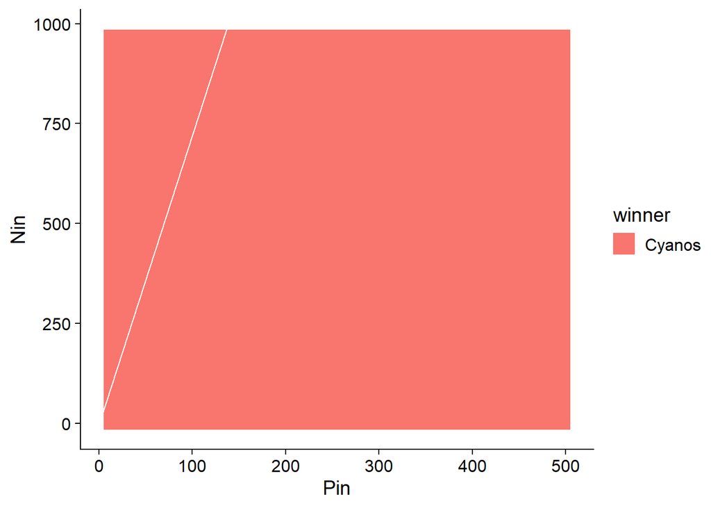

```r
sim.droop.triple.q25 %>%
  ggplot(aes(Pin, Nin, fill = winner)) +
  geom_raster() +
  geom_abline(intercept = 0, slope = (16*14.001)/30.974, col = "white")
```

## 75<sup>th</sup> quantile trait values

### Michaelis-Menten/static stoichiometry

```r
params.mich.trip.q75 <- c(
  # lake parameters
  SA= 1,        # lake surface area in km2
  zmix = 2, # lake mixing depth in m
  Pin = NA, # P inflow concentration in mg P m^-3
  Nin = NA, # N inflow concentration in mg N m^-3

  # light parameters
  I0 = NA, # incident light
  kBg= 0.1,     # background light attenuation (m-1)/(g C m-3); 0.1-5.6 from Jager & Diehl
  kA=0.0003, # algal light attenuation (m-1)/(mg C m-3); 0.0003 from Jager & Diehl

  # algae physiology parameters
  umax1 = traitsq75[12, "diatoms"],
  umax2 = traitsq75[12, "greens"],
  umax3 = traitsq75[12, "cyanos"],
  lA=0.1,           # mortality rate day-1
  v=0.1,            # m d-1; sinking loss of algae
  KLight1 = traitsq75[11, "diatoms"], # light half sat constant
  KLight2 = traitsq75[11, "greens"], # light half sat constant
  KLight3 = traitsq75[11, "cyanos"], # light half sat constant
  KP1 = traitsq75[2, "diatoms"] * 1000, # phosphorus half sat constant in mg P m^-3 f
  KP2 = traitsq75[2, "greens"] * 1000,
  KP3 = traitsq75[2, "cyanos"] * 1000,
  QP1 = traitsq75[6, "diatoms"], # algae cell P quota in mg P mg^-1 C^-1
  QP2 = traitsq75[6, "greens"],
  QP3 = traitsq75[6, "cyanos"],
  KN1 = traitsq75[1, "diatoms"] * 1000, # nitrogen half sat constant in mg N m^-3
  KN2 = traitsq75[1, "greens"] * 1000,
  KN3 = traitsq75[1, "cyanos"] * 1000,
  QN1 = traitsq75[5, "diatoms"], # algae cell N quota in mg N mg^-1 C^-1
  QN2 = traitsq75[5, "greens"],
  QN3 = traitsq75[5, "cyanos"]
)
names(params.mich.trip.q75) <- c("SA", "zmix", "Pin", "Nin", "I0", "kBg", "kA",
                             "umax1", "umax2", "umax3", "lA", "v",
                             "KLight1", "KLight2", "KLight3",
                             "KP1", "KP2", "KP3", "QP1", "QP2", "QP3",
                             "KN1", "KN2", "KN3", "QN1", "QN2", "QN3")
names(params.mich.trip.q75)
```

```
##  [1] "SA"      "zmix"    "Pin"     "Nin"     "I0"      "kBg"     "kA"
##  [8] "umax1"   "umax2"   "umax3"   "lA"      "v"       "KLight1" "KLight2"
## [15] "KLight3" "KP1"     "KP2"     "KP3"     "QP1"     "QP2"     "QP3"
## [22] "KN1"     "KN2"     "KN3"     "QN1"     "QN2"     "QN3"
```

```r
params.mich.trip.q75 <- unlist(params.mich.trip.q75)
```

```r
sim.mich.menten.triple.q75 <- lapply(1:nrow(loads), function(i) {
  params.mich.trip.q75["Pin"] = loads[i, "Pin"]
  params.mich.trip.q75["Nin"] = loads[i, "Nin"]
  y <- c("A1" = 100,
         "A2" = 100,
         "A3" = 100,
         "P" = loads[i, "Pin"],
         "N" = loads[i, "Nin"])

  run <- ode(y, times, parms = params.mich.trip.q75,func = mich.trip)
  return(run[max(times),])

})

sim.mich.menten.triple.q75 <- do.call(rbind, sim.mich.menten.triple.q75)
sim.mich.menten.triple.q75 <- as_data_frame(sim.mich.menten.triple.q75)
sim.mich.menten.triple.q75$Pin <- loads$Pin
sim.mich.menten.triple.q75$Nin <- loads$Nin
sim.mich.menten.triple.q75$NPinflow <- loads$NPinmolar

# Add info on which species one
sim.mich.menten.triple.q75 <- sim.mich.menten.triple.q75 %>%
  mutate(winner = max.col(sim.mich.menten.triple.q75[,2:4]),
         winner = gsub(1, "Diatom", winner),
         winner = gsub(2, "Greens", winner),
         winner = gsub(3, "Cyanos", winner))
table(sim.mich.menten.triple.q75$winner)
```

```
##
## Cyanos Diatom
##    889    111
```

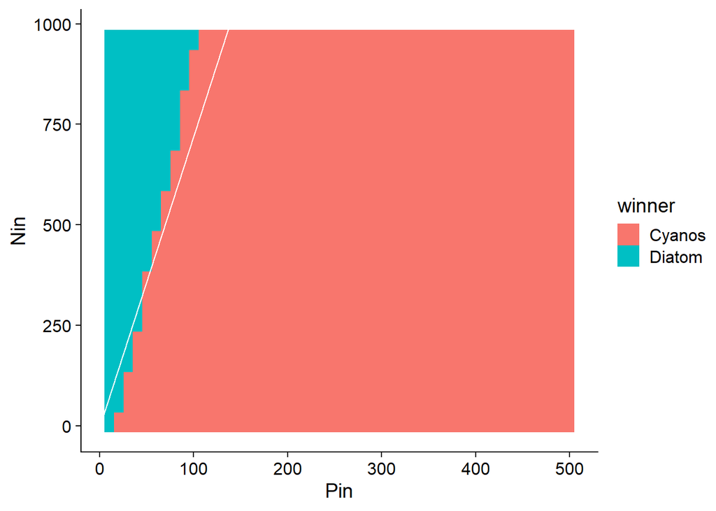

```r
sim.mich.menten.triple.q75 %>%
  ggplot(aes(Pin, Nin, fill = winner)) +
  geom_raster() +
  geom_abline(intercept = 0, slope = (16*14.001)/30.974, col = "white")
```

### Droop formation/flexible stoichiometry with 75<sup>th</sup> percentile traits

```r
params.droop.triple.q75 <- c(
  # lake parameters
  SA= 1,        # lake surface area in km2
  zmix = 2, # lake mixing depth in m
  Pin = NA, # P inflow concentration in mg P m^-3
  Nin = NA, # N inflow concentration in mg N m^-3

  # light parameters
  I0 = NA, # surface light
  kBg= 0.1,     # background light attenuation (m-1)/(g C m-3); 0.1-5.6 from Jager & Diehl
  kA=0.0003, # algal light attenuation (m-1)/(mg C m-3); 0.0003 from Jager & Diehl

  # algae physiology parameters
  umax1 = traitsq75[12, "diatoms"],
  umax2 = traitsq75[12, "greens"],
  umax3 = traitsq75[12, "cyanos"],

  lA=0.1,           # mortality rate day-1
  v= 0.1,           # m d-1; sinking loss of algae
  KLight1 = traitsq75[11, "diatoms"], # light half sat constant
  KLight2 = traitsq75[11, "greens"], # light half sat constant
  KLight3 = traitsq75[11, "cyanos"], # light half sat constant

  KP1 = traitsq75[2, "diatoms"] * 1000, # phosphorus half sat constant in mg P m^-3 f
  KP2 = traitsq75[2, "greens"] * 1000,
  KP3 = traitsq75[2, "cyanos"] * 1000,
  minQP1 = traitsq75[6, "diatoms"], # algae cell P quota in mg P mg^-1 C^-1 f
  minQP2 = traitsq75[6, "greens"],
  minQP3 = traitsq75[6, "cyanos"],
  upP1 = traitsq75[4, "diatoms"], # max uptake rate P per day in mg P mg C^-1 day^-1
  upP2 = traitsq75[4, "greens"],
  upP3 = traitsq75[4, "cyanos"],
  KN1 = traitsq75[1, "diatoms"] * 1000, # nitrogen half sat constant in mg N m^-3
  KN2 = traitsq75[1, "greens"] * 1000,
  KN3 = traitsq75[1, "cyanos"] * 1000,
  minQN1 = traitsq75[5, "diatoms"], # algae cell N quota in mg N mg^-1 C^-1 f
  minQN2 = traitsq75[5, "greens"],
  minQN3 = traitsq75[5, "cyanos"],
  upN1 = traitsq75[3, "diatoms"], # max uptake rate N per day in mg N mg C^-1 day^-1
  upN2 = traitsq75[3, "greens"],
  upN3 = traitsq75[3, "cyanos"]
)



names(params.droop.triple.q75) <- c("SA", "zmix", "Pin", "Nin", "I0", "kBg", "kA",
                             "umax1", "umax2", "umax3", "lA", "v",
                             "KLight1", "KLight2", "KLight3",
                             "KP1", "KP2", "KP3", "minQP1", "minQP2", "minQP3",
                             "upP1", "upP2", "upP3",
                             "KN1", "KN2", "KN3", "minQN1", "minQN2", "minQN3",
                             "upN1", "upN2", "upN3")
names(params.droop.triple.q75)
```

```
##  [1] "SA"      "zmix"    "Pin"     "Nin"     "I0"      "kBg"     "kA"
##  [8] "umax1"   "umax2"   "umax3"   "lA"      "v"       "KLight1" "KLight2"
## [15] "KLight3" "KP1"     "KP2"     "KP3"     "minQP1"  "minQP2"  "minQP3"
## [22] "upP1"    "upP2"    "upP3"    "KN1"     "KN2"     "KN3"     "minQN1"
## [29] "minQN2"  "minQN3"  "upN1"    "upN2"    "upN3"
```

```r
params.droop.triple.q75 <- unlist(params.droop.triple.q75)
```

```r
sim.droop.triple.q75 <- lapply(1:nrow(loads), function(i) {
  params.droop.triple.q75["Pin"] = loads[i, "Pin"]
  params.droop.triple.q75["Nin"] = loads[i, "Nin"]
  y <- c("A1" = 100,
         "A2" = 100,
         "A3" = 100,
         "P" = loads[i, "Pin"],
         "N" = loads[i, "Nin"],
         "QP1" = 0.015,
         "QP2" = 0.015,
         "QP3" = 0.015,
         "QN1" = 0.1,
         "QN2" = 0.1,
         "QN3" = 0.1)

  run <- ode(y, times, parms = params.droop.triple.q75, func = droop.trip)
  return(run[max(times),])

})

sim.droop.triple.q75 <- do.call(rbind, sim.droop.triple.q75)
sim.droop.triple.q75 <- as_data_frame(sim.droop.triple.q75)
sim.droop.triple.q75$Pin <- loads$Pin
sim.droop.triple.q75$Nin <- loads$Nin
sim.droop.triple.q75$NPinflow <- loads$NPinmolar

# Add info on which species one
sim.droop.triple.q75 <- sim.droop.triple.q75 %>%
  mutate(winner = max.col(sim.droop.triple.q75[,2:4]),
         winner = gsub(1, "Diatom", winner),
         winner = gsub(2, "Greens", winner),
         winner = gsub(3, "Cyanos", winner))
table(sim.droop.triple.q75$winner)
```

```
##
## Greens
##   1000
```

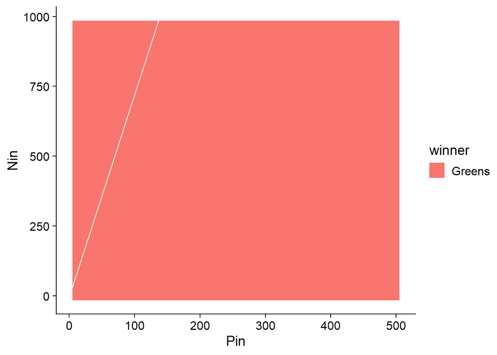

```r
sim.droop.triple.q75 %>%
  ggplot(aes(Pin, Nin, fill = winner)) +
  geom_raster() +
  geom_abline(intercept = 0, slope = (16*14.001)/30.974, col = "white")
```

# Summary/skip to here

This section provides a summary of the 6 simulations and generates some pretty figures.

```r
# Michaelis Menten
all.michaelis <- do.call(rbind, list(
  sim.mich.menten.triple %>% mutate(Trait = "Median"),
  sim.mich.menten.triple.q25 %>% mutate(Trait = "25th quantile"),
  sim.mich.menten.triple.q75 %>% mutate(Trait = "75th quantile")
)) %>%
  mutate(Trait = factor(Trait,
                        levels = c("Median", "25th quantile", "75th quantile")))
# Droop
all.droop <- do.call(rbind, list(
  sim.droop.triple %>% mutate(Trait = "Median"),
  sim.droop.triple.q25 %>% mutate(Trait = "25th quantile"),
  sim.droop.triple.q75 %>% mutate(Trait = "75th quantile")
)) %>%
  mutate(Trait = factor(Trait,
                        levels = c("Median", "25th quantile", "75th quantile")))
```

Create a summary table of the number of competitive outcomes

```r
# Michaelis Menten
comp.out.michaelis <- all.michaelis %>%
  group_by(Trait, winner) %>%
  summarise(n = n(),
            perc.occurence = n*100/100) %>%
  pivot_wider(id_cols = c(winner), names_from = Trait, values_from = perc.occurence)
comp.out.michaelis
```

```
## # A tibble: 2 × 4
##   winner Median `25th quantile` `75th quantile`
##   <chr>   <dbl>           <dbl>           <dbl>
## 1 Cyanos    839             829             889
## 2 Diatom    161             171             111
```

```r
# Droop
comp.out.droop <- all.droop %>%
  group_by(Trait, winner) %>%
  summarise(n = n(),
            perc.occurence = n*100/100) %>%
  pivot_wider(id_cols = c(winner), names_from = Trait, values_from = perc.occurence)
comp.out.droop
```

```
## # A tibble: 3 × 4
##   winner Median `25th quantile` `75th quantile`
##   <chr>   <dbl>           <dbl>           <dbl>
## 1 Diatom     51              NA              NA
## 2 Greens    949              NA            1000
## 3 Cyanos     NA            1000              NA
```

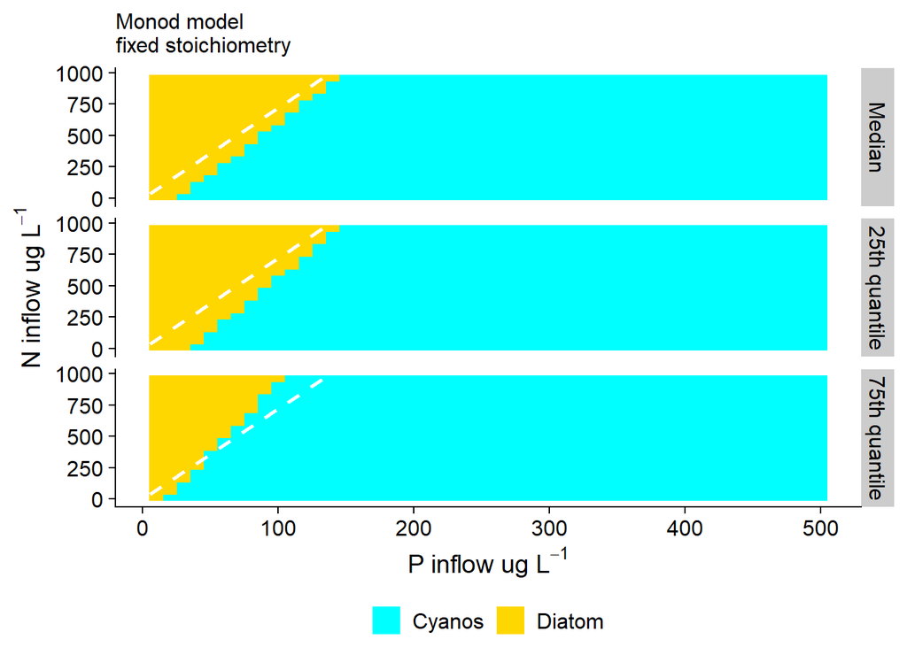

```r
(michaelis.figure <- all.michaelis %>%
  ggplot(aes(Pin, Nin, fill = winner)) +
  geom_raster() +
  facet_grid(Trait ~ .) +
  geom_abline(slope = 16*14.007/30.974, col = "white", lty = "dashed", lwd = 1) +
  #scale_fill_jco() +
  scale_fill_manual(
    values = c("Diatom" = "gold",
               "Greens" = "forestgreen",
               "Cyanos" = "cyan")
  ) +
  labs(x = expression("P inflow ug L"^-1), y = expression("N inflow ug L"^-1),
       fill = NULL,
       subtitle = "Monod model \nfixed stoichiometry")) +
  theme(legend.position = "bottom")
```

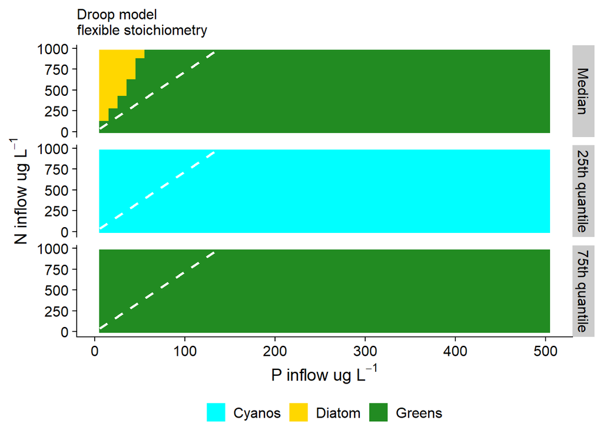

```r
(droop.figure <- all.droop %>%
  ggplot(aes(Pin, Nin, fill = winner)) +
  geom_raster() +
  facet_grid(Trait ~ .) +
  geom_abline(slope = 16*14.007/30.974, col = "white", lty = "dashed", lwd = 1) +
  #scale_fill_jco() +
  scale_fill_manual(
    values = c("Diatom" = "gold",
               "Greens" = "forestgreen",
               "Cyanos" = "cyan")
  ) +
  labs(x = expression("P inflow ug L"^-1), y = expression("N inflow ug L"^-1),
       fill = NULL,
       subtitle = "Droop model \nflexible stoichiometry")) +
  theme(legend.position = "bottom")
```

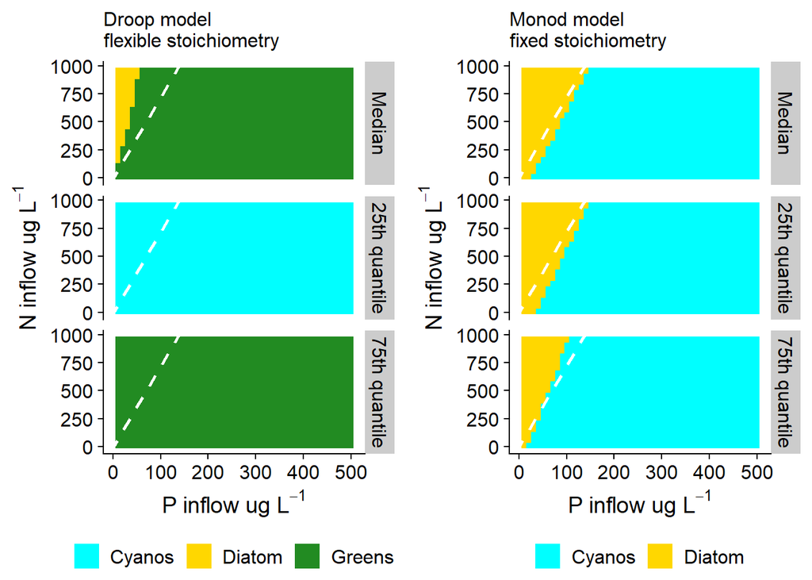

```r
final.fig <- ggpubr::ggarrange(plotlist = list(droop.figure, michaelis.figure),
                               ncol = 2, nrow = 1, align = "hv",
                               legend = "bottom")

final.fig
```

```r
ggsave2("competition simulations no light.jpg",
        final.fig, width = 12, height = 8)
```